# Resumen Taller R

Generación 2019

Tenemos el siguiente archivo de extensión .txt:

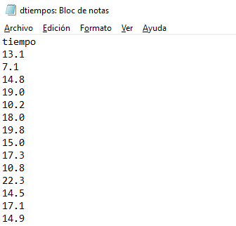

**Para cargar el archivo a R**

```r
datos<- read.table("dtiempos.txt", header=TRUE)
```

`header = TRUE` Indica que el archivo posee encabezado, en este caso el header es **tiempo**

**Cargar el archivo manualmente**

```r
# datos2 <- read.table(file.choose(), header=TRUE)
```

Luego los datos que estaban en el archivo `dtiempos.txt` quedaron almacenada en la variable `datos`. A esta variable podemos hacer una variedad de operaciones, dentro de las cuales tenemos:

**Resumen de la base de datos**

```r
summary(datos)
```

```
##      tiempo
##  Min.   : 4.20
##  1st Qu.:13.18
##  Median :15.25
##  Mean   :15.50
##  3rd Qu.:18.15
##  Max.   :26.70
```

Dentro de los datos, se pueden tener distintas variables, en este caso solo está la variable `tiempo`, definiendola en `a`:

```r
a <- table(datos$tiempo)
```

Para abarcar todas las variables de manera automática:

```r
attach(datos)
```

Consultas a variable `tiempo`:

**Promedio**

```r
mean(tiempo)
```

**Mediana**

```r
median(tiempo)
```

**Varianza**

```r
var(tiempo)
```

**Desviación estándar**

```r
sd(tiempo)
```

**Longitud**

```r
length(tiempo)
```

**Cuartiles**

```r
quantile(tiempo)
```

```
##     0%    25%    50%    75%   100%
##  4.200 13.175 15.250 18.150 26.700
```

**Percentiles puntuales**

- ejemplo: 15%, 20%, 45%, 90%

```r
quantile(tiempo, c(.15, .2, .45, .90))
```

```
##    15%    20%    45%    90%
## 11.135 12.320 14.905 21.020
```

**Deciles**

```r
quantile(tiempo, probs=seq(from=0, to=1, by=0.1))
```

```
##    0%   10%   20%   30%   40%   50%   60%   70%   80%   90%  100%
##  4.20 10.20 12.32 13.71 14.62 15.25 16.76 17.93 18.92 21.02 26.70
```

**RIC** $(Q_3 - Q_1)$

```r
IQR(tiempo)
```

## Gráficos

**Histograma (default)**

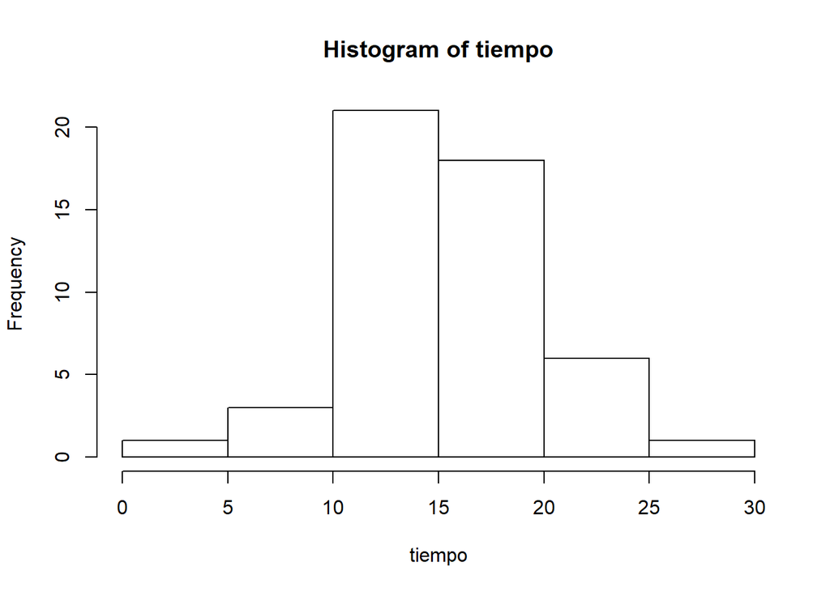

```r
hist(tiempo)
```

**Histograma con parámetros**

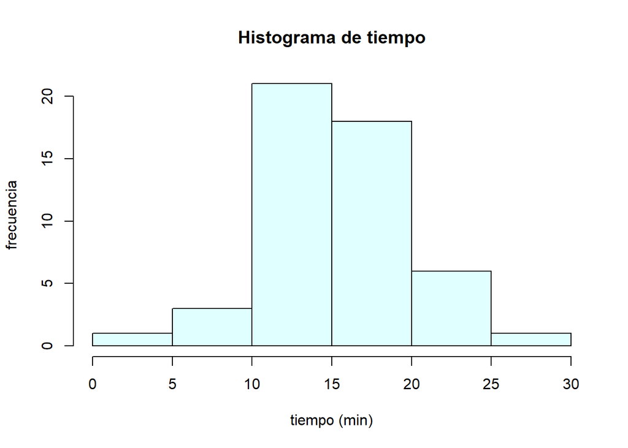

```r
hist(tiempo, main="Histograma de tiempo", col="lightcyan", xlab="tiempo (min)", ylab="frecuencia")
```

**Diagrama de caja**

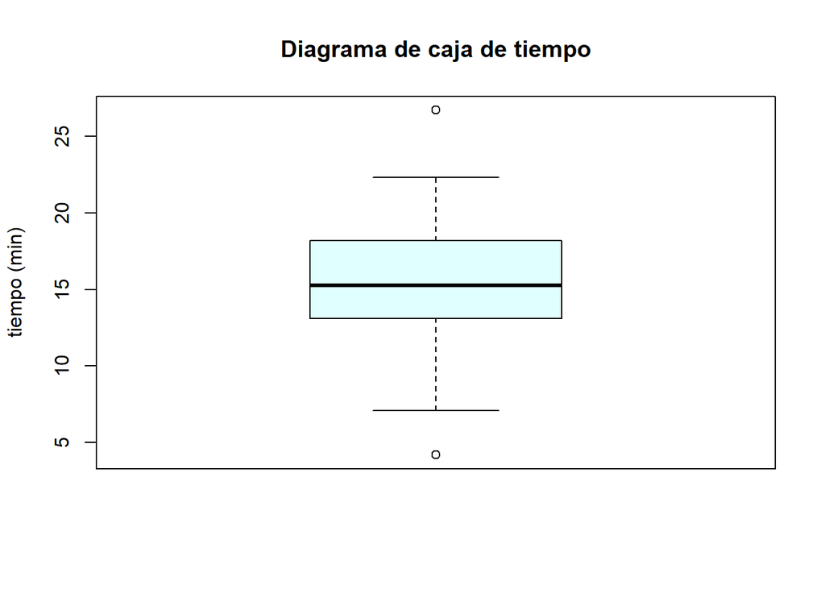

```r
boxplot(tiempo, main="Diagrama de caja de tiempo", col="lightcyan", ylab="tiempo (min)")
```

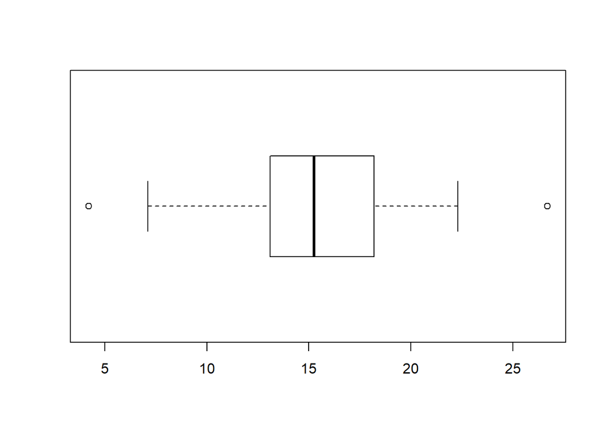

```r
boxplot(tiempo, horizontal = TRUE)
```

**Diagrama de tallo y hoja (default)**

```r
stem(tiempo)
```

```
##
##   The decimal point is at the |
##
##    4 | 2
##    6 | 14
##    8 | 3
##   10 | 22812
##   12 | 0491458
##   14 | 03457890058
##   16 | 05601369
##   18 | 00249088
##   20 | 2022
##   22 | 03
##   24 |
##   26 | 7
```

**Diagrama de tallo y hoja con parámetros**

```r
stem(tiempo, seq(from=4, to=27, by=1))
```

```
##
##   The decimal point is at the |
##
##    4 | 2
##    5 |
##    6 |
##    7 | 14
##    8 | 3
##    9 |
##   10 | 228
##   11 | 12
##   12 | 049
##   13 | 1458
##   14 | 0345789
##   15 | 0058
##   16 | 056
##   17 | 01369
##   18 | 00249
##   19 | 088
##   20 | 2
##   21 | 022
##   22 | 03
##   23 |
##   24 |
##   25 |
##   26 | 7
```

Bibliografía y sitios de interés:

- https://www.rstudio.com/wp-content/uploads/2015/03/rmarkdown-spanish.pdf
- https://rpubs.com/osoramirez/93049
- https://rpubs.com/Charlie_A/
- https://www.calvin.edu/~rpruim/courses/s341/S17/from-class/MathinRmd.html
- http://zevross.com/blog/2017/06/19/tips-and-tricks-for-working-with-images-ad-figures-in-r-markdown-documents/
- https://tex.stackexchange.com/questions/339191/is-it-possible-to-write-the-symbol-in-text-in-latex
- https://cran.r-project.org/doc/contrib/grafi3.pdf
- http://www.dma.ulpgc.es/profesores/personal/stat/cursoR4ULPGC/9c-grafHistograma.html
- https://picandoconr.wordpress.com/2016/02/08/graficos-con-r-histogramas/